# Problem Set #2

Jaclynn Martinez

2026-10-31

# Q.1

```r
set.seed(22)
n=1000 #number of observations
num_sim=1000 # number of simulations
p<-0.5 #covariance

beta_one<- numeric(num_sim) #empty vector to hold beta_one coefficients
varcov<-matrix(c(1,p,p,1),2,2) #covariance matrix and specifying a 2x2 matrix.

for (i in 1:num_sim) {
  covariates<-mvrnorm(n,mu=c(1,2),Sigma=varcov) #using mvrnorm to simulate random data. n= number of observations. mu= mean of variable. X will have a mean of 1. Z will have a mean of 2. Sigma= the covariance matrix
  colnames(covariates)<-c('X','Z') # nameing the columns
  covariates <- as.data.frame(covariates) # converting into a dataframe
  X<-covariates[,1] #taking values from the first column of the covariate matrix.
  Z<-covariates[,2] #taking values from the second column of the covariate matrix.
  e<-rnorm(n) #random error
  y<- 2+ 5*X + 3*Z+e # DGP

  model<- lm(y ~X+Z) #linear regression
  beta_one[i] <- coef(model)["X"]
  #creating a vector of my treatment coefficients using the empty vector made in the beginning.
}

beta1<-data.frame(beta1=beta_one) #converting vector into dataframe.
```

### 1.a

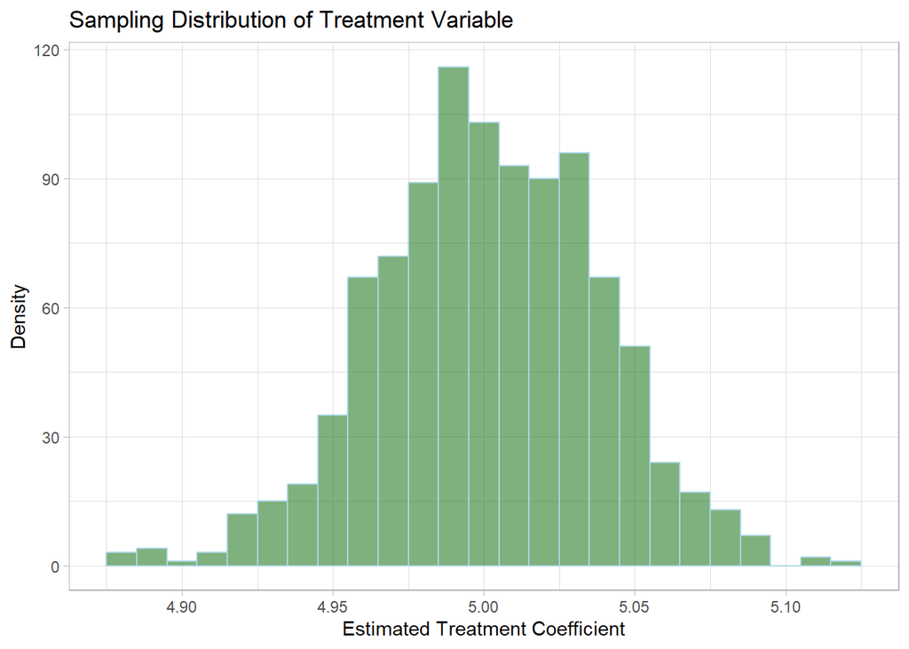

```r
#plotting the sampling distribution
ggplot(beta1,aes(x=beta1))+
  geom_histogram(bins = 60,binwidth= 0.01, fill="darkgreen",color="lightblue", alpha=0.5)+
  labs(title="Sampling Distribution of Treatment Variable",
       x= "Estimated Treatment Coefficient",
       y= "Density")+
  theme_light()
```

### 1.b

```r
set.seed(220)
samples <- 1000  # number of bootstrap replicates
n <- length(beta_one)   # setting length to be the same as the length of the beta_one vector
boot_means <- numeric(samples) # empty vector to hold beta_means values

#creating a for loop to run repeated simulations for the bootstrapped standard errors using mean.
for (b in 1:samples) {
  idbeta_one <- sample(seq_len(n), size = n, replace = TRUE) # idbeta_one will create many different samples of the same length as n. Replace= TRUE allows for numbers to repeated.
  boot_means[b] <- mean(beta_one[idbeta_one]) # new samples will be stored in the boot_means vector.
}

boot_df <- data.frame(boot_mean = boot_means) # converting into a data frame
boot_summary <- data.frame(
  estimate = mean(beta_one),
  boot_se  = sd(boot_means),  # bootstrapped standard errors are calculated by getting the standard deviation of the boot_means
  ci_lower = as.numeric(quantile(boot_means, 0.025)), # setting the confidence intervals
  ci_upper = as.numeric(quantile(boot_means, 0.975))
)

# The bootstrap standard error
boot_summary$boot_se
```

```
## [1] 0.001199092
```

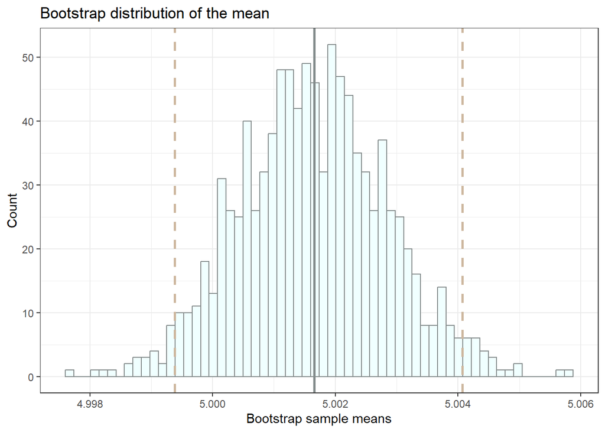

```r
#Bootstrap plot
ggplot(boot_df, aes(x = boot_mean)) +
  geom_histogram( bins=60,fill = "#F0FFFF", colour = "#838B8B") +
  geom_vline(aes(xintercept = estimate),  data = boot_summary,
             colour = "#838B8B", linewidth = 1) +
  geom_vline(aes(xintercept = ci_lower),  data = boot_summary,
             colour = "#CDB79E", linetype = "dashed", linewidth = 1) +
  geom_vline(aes(xintercept = ci_upper),  data = boot_summary,
             colour = "#CDB79E", linetype = "dashed", linewidth = 1) +
  labs(
    title    = "Bootstrap distribution of the mean",
    x = "Bootstrap sample means", y = "Count"
  ) +
  theme_bw()
```

### 1.c

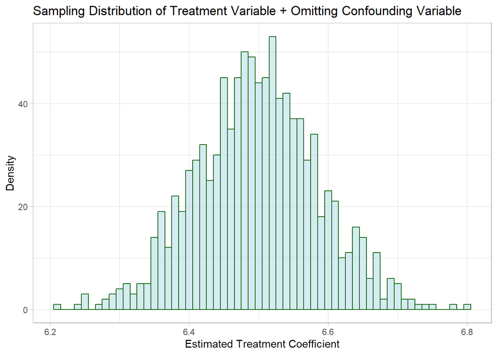

```r
set.seed(567)
n=1000 #number of observations
num_sim=1000 # number of simulations
p<-0.5 #covariance

beta_1<- numeric(num_sim) #empty vector to hold beta_one coefficients
varcov.c<-matrix(c(1,p,p,1),2,2) #covariance matrix and specifying a 2x2 matrix.

for (i in 1:num_sim) {
  covariates.c<-mvrnorm(n,mu=c(1,2),Sigma=varcov.c) #using mvrnorm to simulate random data. n= number of observations. mu= mean of variable. X will have a mean of 1. Z will have a mean of 2. Sigma= the covariance matrix
  colnames(covariates.c)<-c('X','Z') # naming the columns
  covariates.c <- as.data.frame(covariates.c) # converting into a data frame
  X.c<-covariates.c[,1] #taking values from the first column of the co-variate matrix.
  Z.c<-covariates.c[,2] #taking values from the second column of the co-variate matrix.
  e.c<-rnorm(n) #random error
  y.c<- 2+ 5*X.c + 3*Z.c+e.c # DGP

  model2<- lm(y.c ~X.c) #linear regression omitting confounding variable.
  beta_1[i] <- coef(model2)["X.c"]
  #creating a vector of my treatment coefficients using the empty vector made in the beginning.
}

beta.c<-data.frame(beta.c=beta_1) #converting vector into data frame.

#plotting the sampling distribution
ggplot(beta.c,aes(x=beta.c))+
  geom_histogram(binwidth=0.01,fill="lightblue",color="darkgreen", alpha=0.5)+
  labs(title="Sampling Distribution of Treatment Variable + Omitting Confounding Variable",
       x= "Estimated Treatment Coefficient",
       y= "Density")+
  theme_light()
```

Interpretation: This new distribution is biased and the statistical tests can no longer be used to determine causal effects.

# Problem 2

```r
df<-read.csv("voting.csv") #loading in 'voting' data from the github
str(df)
```

```
## 'data.frame':    229444 obs. of  3 variables:
##  $ birth  : int  1981 1959 1956 1939 1968 1967 1941 1969 1967 1961 ...
##  $ message: chr  "no" "no" "no" "yes" ...
##  $ voted  : int  0 1 1 1 0 0 1 0 1 1 ...
```

### 2.a

Null Hypothesis:Receiving a message had no effect on someones probability to vote. Hypothesis: Receiving a message did have an effect on the probability to vote.

```r
set.seed(4563)
t.test(voted~message,data= df,alternative="two.sided",var.equal= FALSE,  conf.level = 0.95)
```

```
##
##  Welch Two Sample t-test
##
## data:  voted by message
## t = -30.207, df = 52613, p-value < 2.2e-16
## alternative hypothesis: true difference in means between group no and group yes is not equal to 0
## 95 percent confidence interval:
##  -0.08658577 -0.07603405
## sample estimates:
##  mean in group no mean in group yes
##         0.2966383         0.3779482
```

### 2.b

```r
set.seed(6583)
# I am changing the character values in the data set into numbers so that it can be run through the linear model.
df$message[df$message=="no"]<-0
df$message[df$message=="yes"]<-1

model<-lm(voted~message,data=df)

summary(model)
```

```
##
## Call:
## lm(formula = voted ~ message, data = df)
##
## Residuals:
##     Min      1Q  Median      3Q     Max
## -0.3780 -0.2966 -0.2966  0.6220  0.7034
##
## Coefficients:
##             Estimate Std. Error t value Pr(>|t|)
## (Intercept) 0.296638   0.001055  281.05   <2e-16 ***
## message1    0.081310   0.002587   31.43   <2e-16 ***
## ---
## Signif. codes:  0 '***' 0.001 '**' 0.01 '*' 0.05 '.' 0.1 ' ' 1
##
## Residual standard error: 0.4616 on 229442 degrees of freedom
## Multiple R-squared:  0.004288,   Adjusted R-squared:  0.004284
## F-statistic: 988.1 on 1 and 229442 DF,  p-value: < 2.2e-16
```

*Coefficient:* When people did receive a message their chance of voting increased by 8.1%.

*Standard Error:* The standard error for when people did receive a message is 0.0026; This tells us that the estimate is close to the population true value. It also tells us that there is low variance in our estimate.

*T-Value:* A t-value score of 31.4 tells us that there is a positive relationship between receiving a message and the probability of voting. A large t-score tells us that the relationship is strong between receiving a message and the chance of voting.

*P-Value:* The p-value comes out to be significant. This tells us that we can reject the null hypothesis.

### 2.c

```r
set.seed(890)
# difference of means of the data
dif.means<- mean(df$voted[df$message== 1 ])-
  mean(df$voted[df$message==0])

# difference of means of the null distribution
perm<- replicate(1000,{
  mix<- sample(df$message)
  mean(df$voted[mix==1])- mean(df$voted[mix==0])
  })
# comparing the difference between the null distribution and the data.
comp<-mean(abs(perm)>= abs(dif.means)) #p-value for the permutation test.

comp
```

```
## [1] 0
```

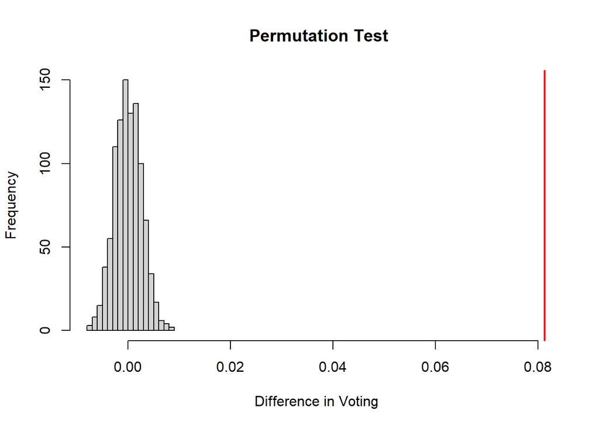

```r
View(dif.means)

#plot

hist(perm, breaks = 20, xlim= range(c(perm, dif.means)),
     main = " Permutation Test",
     xlab = "Difference in Voting")
abline(v = dif.means, col = "red", lwd = 2)
```

The permutation result being 0 allows us to reject the null. This small value tells us that there is an existing relationship between receiving a message and voting. Both p-values from parts a and b are also essentially 0 allowing us to reject the null as well.